# Problem Set 2

Omry Yoresh

2023-05-16

Load the packages:

```r
library(tidyverse)
library(kableExtra)
library(datasets)
library(DataExplorer)
library(tidymodels)
library(rsample)
library(skimr)
library(fixest)
library(GGally)
library(broom)
library(glmnet)
```

Setting the seed:

```r
set.seed(100)
```

# Exercises:

- *Q1*: Can we use the data for prediction without assumptions? Why?
- *A1*: Yes, we don’t need any assumption, since our interest is in predicting values of a variable of interest (dependent) and not deriving any claim on the causal effect of any one of the co-variate.
- Separability
- *Q2*: What is the downside in adding interactions? (Hint: think about the ratio n/k, where n is the number of observations and k is the number of co-variates)
- *A2*: The downside of adding interactions is that more complexity is integrated into the model. The complexity of the model will lead to over fitting of the data and although it’s more accurate, the less we will be able to gain from it.
- Normal Distribution of E(u|X)
- *Q3*: Why is those assumptions strong? Can you come up with a story that wouldn’t fit?
- *A3*: This assumption is strong, and mostly unrelevant to modern econometrics as you can overcome this assumptions in various ways and more importantly check if indeed that is the case of the error terms. Main findings and stories in which this condition isn’t met is when the error term is actually skewed, which happens when dealing with variables as income or education as the dependent variable, which are skewed themselves.
- *Q4*: The confidence intervals of the β are derived from those assumptions. Explain how the confidence intervals derived from the assumptions (Intuitive explanation is enough).
- *Q4*: In introductory to econometrics we used those assumptions in order to derive the confidence interval, as the confidence interval are calculated by relying on trying to rule out the H0 which is if the betas are different than zero – the normality assumption, and in that equation it’s also reliant on the beta being a constant number – linearity.

Loading the data:

```r
heart <- read_csv("data/ml4econ ex2 heart.csv")
wine <- read_csv("data/ml4econ ex2 winequality_red.csv")
```

Plotting the histograms of every variable in the wine data:

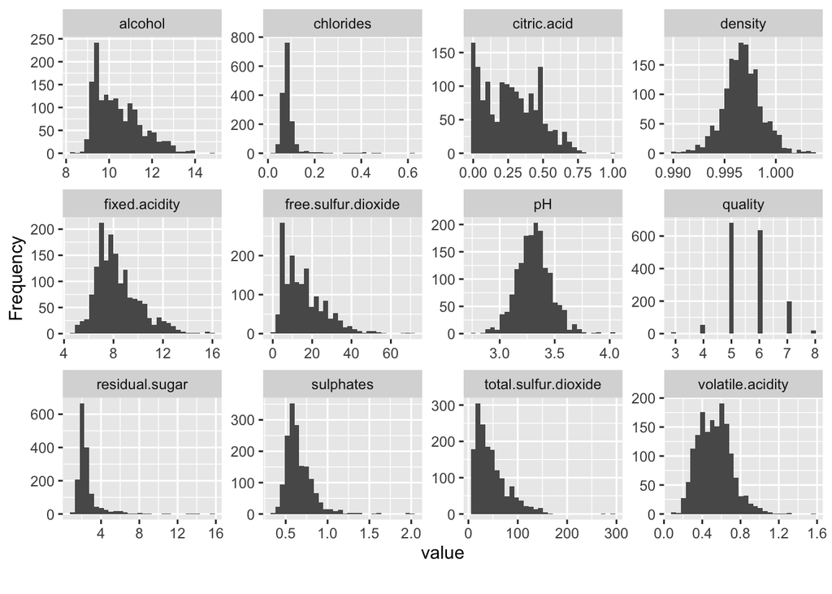

```r
plot_histogram(wine)
```

Creating box-plots of every variable in the wine data against the quality of the wine:

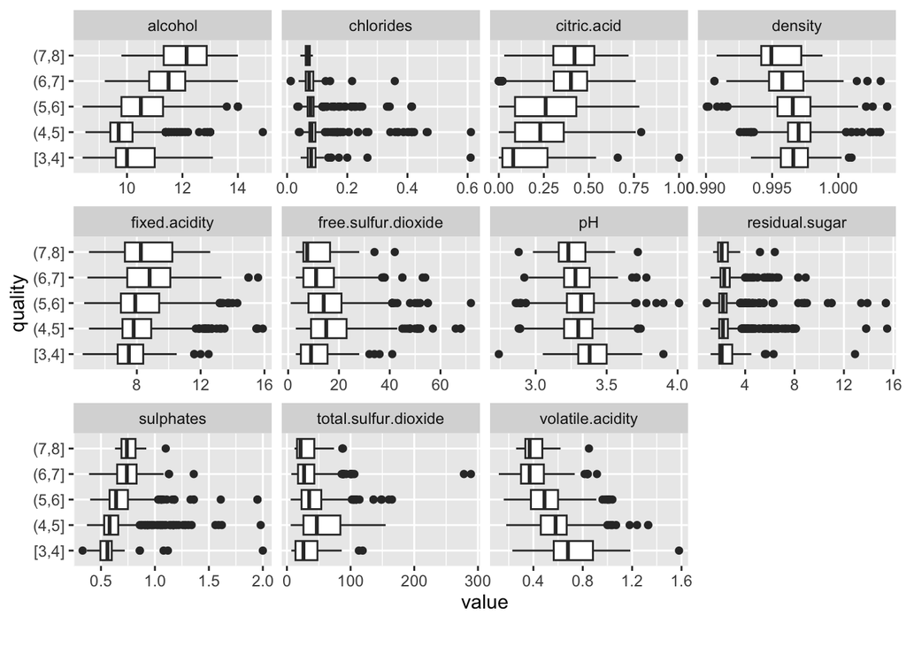

```r
plot_boxplot(wine, by = "quality")
```

Splitting the data into 70% train and 30% test:

```r
wine_split <- wine %>%
  initial_split(prop=7/10)

wine_train <- training(wine_split)
wine_test  <- testing(wine_split)
```

Skimming the training data:

```r
wine_train %>%
  skim()
```

Data summary

| Name | Piped data |
| --- | --- |
| Number of rows | 1119 |
| Number of columns | 12 |
| _______________________ |  |
| Column type frequency: |  |
| numeric | 12 |
| ________________________ |  |
| Group variables | None |

**Variable type: numeric**

| skim_variable | n_missing | complete_rate | mean | sd | p0 | p25 | p50 | p75 | p100 | hist |
| --- | --- | --- | --- | --- | --- | --- | --- | --- | --- | --- |
| fixed acidity | 0 | 1 | 8.30 | 1.73 | 4.70 | 7.10 | 7.90 | 9.30 | 15.50 | ▂▇▃▁▁ |
| volatile acidity | 0 | 1 | 0.53 | 0.18 | 0.12 | 0.39 | 0.52 | 0.64 | 1.58 | ▅▇▂▁▁ |
| citric acid | 0 | 1 | 0.27 | 0.20 | 0.00 | 0.09 | 0.26 | 0.43 | 1.00 | ▇▆▅▁▁ |
| residual sugar | 0 | 1 | 2.52 | 1.37 | 0.90 | 1.90 | 2.20 | 2.60 | 15.50 | ▇▁▁▁▁ |
| chlorides | 0 | 1 | 0.09 | 0.05 | 0.01 | 0.07 | 0.08 | 0.09 | 0.61 | ▇▁▁▁▁ |
| free sulfur dioxide | 0 | 1 | 15.95 | 10.60 | 1.00 | 7.00 | 14.00 | 22.00 | 72.00 | ▇▅▂▁▁ |
| total sulfur dioxide | 0 | 1 | 46.03 | 32.16 | 6.00 | 22.00 | 38.00 | 61.00 | 289.00 | ▇▂▁▁▁ |
| density | 0 | 1 | 1.00 | 0.00 | 0.99 | 1.00 | 1.00 | 1.00 | 1.00 | ▁▃▇▂▁ |
| pH | 0 | 1 | 3.31 | 0.16 | 2.74 | 3.21 | 3.31 | 3.40 | 4.01 | ▁▅▇▂▁ |
| sulphates | 0 | 1 | 0.66 | 0.17 | 0.33 | 0.55 | 0.62 | 0.73 | 2.00 | ▇▅▁▁▁ |
| alcohol | 0 | 1 | 10.42 | 1.06 | 8.40 | 9.50 | 10.20 | 11.03 | 14.00 | ▆▇▅▂▁ |
| quality | 0 | 1 | 5.62 | 0.79 | 3.00 | 5.00 | 6.00 | 6.00 | 8.00 | ▁▇▇▂▁ |

Fitting the linear model:

```r
lm_mod <- linear_reg()%>%
  set_engine("lm")

wine_train_fit <- lm_mod %>%
  fit(quality ~ ., data = wine_train)

wine_train_fit
```

```
## parsnip model object
##
##
## Call:
## stats::lm(formula = quality ~ ., data = data)
##
## Coefficients:
##            (Intercept)         `fixed acidity`      `volatile acidity`
##              36.496311                0.035290               -1.073816
##          `citric acid`        `residual sugar`               chlorides
##              -0.234237                0.033226               -1.729167
##  `free sulfur dioxide`  `total sulfur dioxide`                 density
##               0.002321               -0.002840              -32.848020
##                     pH               sulphates                 alcohol
##              -0.345192                0.847516                0.283058
```

```r
wine_test_pred <- wine_train_fit %>%
  predict(new_data = wine_test) %>%
  bind_cols(wine_test) %>%
  select(quality, .pred)

head(wine_test_pred)
```

```
## # A tibble: 6 × 2
##   quality .pred
##     <dbl> <dbl>
## 1       5  5.01
## 2       5  5.10
## 3       7  5.35
## 4       7  5.32
## 5       5  5.69
## 6       5  5.85
```

```r
wine_test_pred %>%
  rmse(quality, .pred)
```

```
## # A tibble: 1 × 3
##   .metric .estimator .estimate
##   <chr>   <chr>          <dbl>
## 1 rmse    standard       0.692
```

```r
wine_test_pred %>%
  rsq(quality, .pred)
```

```
## # A tibble: 1 × 3
##   .metric .estimator .estimate
##   <chr>   <chr>          <dbl>
## 1 rsq     standard       0.324
```

```r
wine_test_pred %>%
  mae(quality, .pred)
```

```
## # A tibble: 1 × 3
##   .metric .estimator .estimate
##   <chr>   <chr>          <dbl>
## 1 mae     standard       0.532
```

- *Q5*: Confidence intervals and t-test are essential parts of determining whether we estimated the “real” β or not. RMSE also helps to assert whether your model is correct or not. What is the main difference between these tests?
- *A5*: The difference is that the latter tests are to determine the quality of prediction, calculating based on the predictions and the actual values.

```r
head(heart)
```

```
## # A tibble: 6 × 14
##     age   sex    cp trestbps  chol   fbs restecg thalach exang oldpeak slope
##   <dbl> <dbl> <dbl>    <dbl> <dbl> <dbl>   <dbl>   <dbl> <dbl>   <dbl> <dbl>
## 1    63     1     3      145   233     1       0     150     0     2.3     0
## 2    37     1     2      130   250     0       1     187     0     3.5     0
## 3    41     0     1      130   204     0       0     172     0     1.4     2
## 4    56     1     1      120   236     0       1     178     0     0.8     2
## 5    57     0     0      120   354     0       1     163     1     0.6     2
## 6    57     1     0      140   192     0       1     148     0     0.4     1
## # ℹ 3 more variables: ca <dbl>, thal <dbl>, target <dbl>
```

Plotting the histograms of every variable in the heart data:

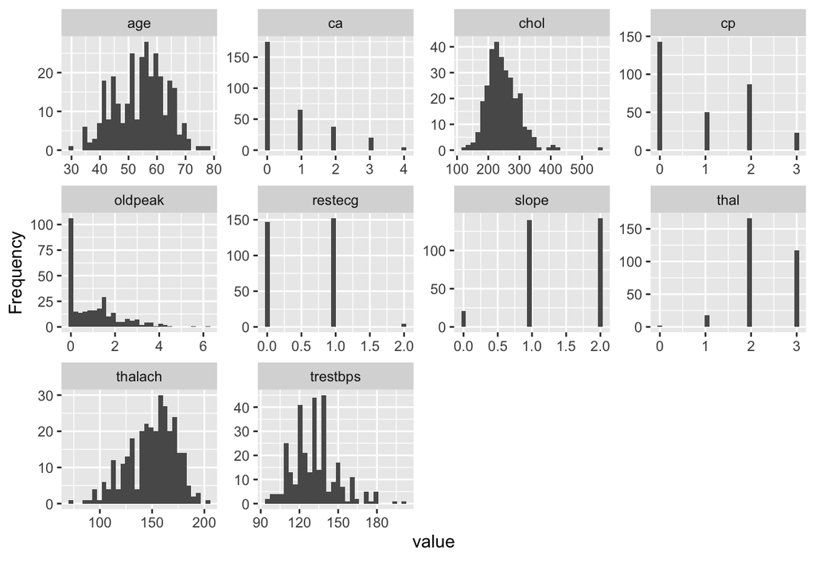

```r
plot_histogram(heart)
```

- *Q6*: Can we use linear regression for binary outcomes? Why?
- *A6*: We can, however, our results will not be bounded between 0 and 1, and so it may contradict the basic probability condition.

Splitting the data into 70% train and 30% test:

```r
heart_split <- heart %>%
  initial_split(prop=7/10)

heart_train <- training(heart_split)
heart_test  <- testing(heart_split)
```

Fitting the linear model :

```r
lm_mod <- linear_reg()%>%
  set_engine("lm")

heart_train_fit <- lm_mod %>%
  fit(target ~ ., data = heart_train)

heart_train_fit
```

```
## parsnip model object
##
##
## Call:
## stats::lm(formula = target ~ ., data = data)
##
## Coefficients:
## (Intercept)          age          sex           cp     trestbps         chol
##   5.825e-01   -1.526e-03   -1.746e-01    1.404e-01   -4.251e-05   -3.365e-04
##         fbs      restecg      thalach        exang      oldpeak        slope
##   1.562e-02    3.684e-02    2.171e-03   -1.971e-01   -2.073e-02    1.331e-01
##          ca         thal
##  -1.088e-01   -1.142e-01
```

```r
heart_test_pred <- heart_train_fit %>%
  predict(new_data = heart_test) %>%
  bind_cols(heart_test) %>%
  select(target, .pred)

heart_test_pred %>%
  summarise(
    max = max(.pred, na.rm = T),
    min = min(.pred, na.rm = T)
)
```

```
## # A tibble: 1 × 2
##     max    min
##   <dbl>  <dbl>
## 1  1.09 -0.295
```

- *Q7*: Is there any problem with these numbers?
- *A7*: They aren’t between [0,1].

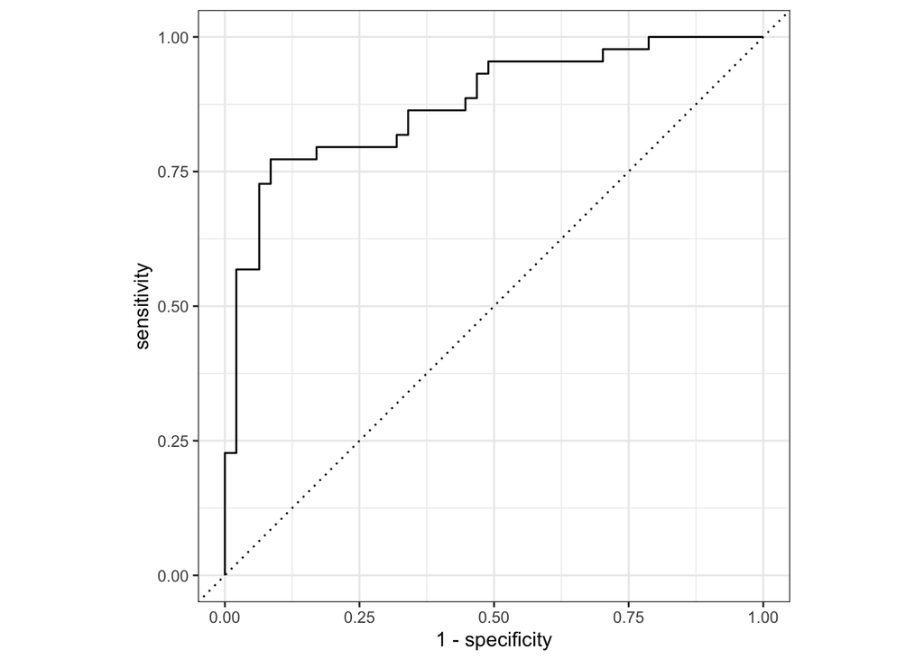

```r
heart_test_pred %>%
  mutate(
    fitted = 1-.pred,
    target = as.factor(target)
         ) %>%
  roc_curve(target, fitted) %>%
  autoplot()
```

Fitting the logistic model :

```r
logit_mod <- glm(
  target ~ .,
  data = heart_train,
  family = "binomial"
)

summary(logit_mod)
```

```
##
## Call:
## glm(formula = target ~ ., family = "binomial", data = heart_train)
##
## Deviance Residuals:
##     Min       1Q   Median       3Q      Max
## -2.5673  -0.3496   0.1407   0.5111   2.6802
##
## Coefficients:
##              Estimate Std. Error z value Pr(>|z|)
## (Intercept)  1.030971   3.063634   0.337 0.736480
## age         -0.003820   0.030803  -0.124 0.901303
## sex         -1.831780   0.591282  -3.098 0.001948 **
## cp           1.087675   0.254804   4.269 1.97e-05 ***
## trestbps    -0.005568   0.012451  -0.447 0.654721
## chol        -0.005571   0.005181  -1.075 0.282209
## fbs         -0.095077   0.759824  -0.125 0.900420
## restecg      0.458778   0.426723   1.075 0.282320
## thalach      0.021353   0.013010   1.641 0.100742
## exang       -1.471538   0.568668  -2.588 0.009662 **
## oldpeak     -0.132660   0.277906  -0.477 0.633109
## slope        1.123189   0.445571   2.521 0.011709 *
## ca          -0.852984   0.240147  -3.552 0.000382 ***
## thal        -0.966420   0.356107  -2.714 0.006651 **
## ---
## Signif. codes:  0 '***' 0.001 '**' 0.01 '*' 0.05 '.' 0.1 ' ' 1
##
## (Dispersion parameter for binomial family taken to be 1)
##
##     Null deviance: 291.17  on 211  degrees of freedom
## Residual deviance: 142.62  on 198  degrees of freedom
## AIC: 170.62
##
## Number of Fisher Scoring iterations: 6
```

```r
heart_log_pred <-
  logit_mod %>%
  augment(
    type.predict = "response",
    newdata = heart_test
    ) %>%
  select(target, .fitted)


heart_log_pred %>%
  summarise(
    max = max(.fitted, na.rm = T),
    min = min(.fitted, na.rm = T)
)
```

```
## # A tibble: 1 × 2
##     max     min
##   <dbl>   <dbl>
## 1 0.993 0.00112
```

```r
rule <- 0.8

heart_log_pred_decision <- heart_log_pred %>%
  mutate(
    decision = if_else(.fitted < rule, "0", "1"),
  )

heart_log_pred_decision
```

```
## # A tibble: 91 × 3
##    target .fitted decision
##     <dbl>   <dbl> <chr>
##  1      1  0.928  1
##  2      1  0.855  1
##  3      1  0.728  0
##  4      1  0.264  0
##  5      1  0.905  1
##  6      1  0.457  0
##  7      1  0.342  0
##  8      1  0.702  0
##  9      1  0.970  1
## 10      1  0.0971 0
## # ℹ 81 more rows
```

```r
heart_conf_mat <-
  heart_log_pred_decision %>%
  mutate(
    target = as.factor(target),
    decision = as.factor(decision)
  ) %>%
  conf_mat(target, decision)

heart_conf_mat
```

```
##           Truth
## Prediction  0  1
##          0 39 22
##          1  5 25
```

```r
heart_conf_mat%>%
  summary() %>%
  filter(.metric %in% c("accuracy", "sens", "spec"))
```

```
## # A tibble: 3 × 3
##   .metric  .estimator .estimate
##   <chr>    <chr>          <dbl>
## 1 accuracy binary         0.703
## 2 sens     binary         0.886
## 3 spec     binary         0.532
```

Ridge: * *Q8*: Another version of regularized regression is the LASSO in which the penalty is in absolute term (in other context these regularizations also called L1 and L2 regularization after their norm term). Why it is necessary to use absolute or square term in the penalty? * *A8*: As in minimizing the mean square errors, we need to use the penalty in absolute or squared term because some coefficients can be negative and some positive and we wont want it to be canceled out.

- *Q9*: One of the features of lasso is “Variable Selection” - some of the co-variates end up as zeros. This does not happen in Ridge. Why?
- *A9*: As we saw in the lecture, the L1 penalty used in lasso encourages sparsity in the coefficients. It pushes the coefficients of less influential features towards zero. Ridge employs an L2 penalty doesn’t always drive coefficients to exactly zero. Instead, it shrinks the coefficient values towards zero without entirely eliminating it. The reason for this stems from the shape of the regularization constrains, the L1 penalty is a diamond-shaped where the L2 is circular – where the latter doesn’t intersect with the axes.

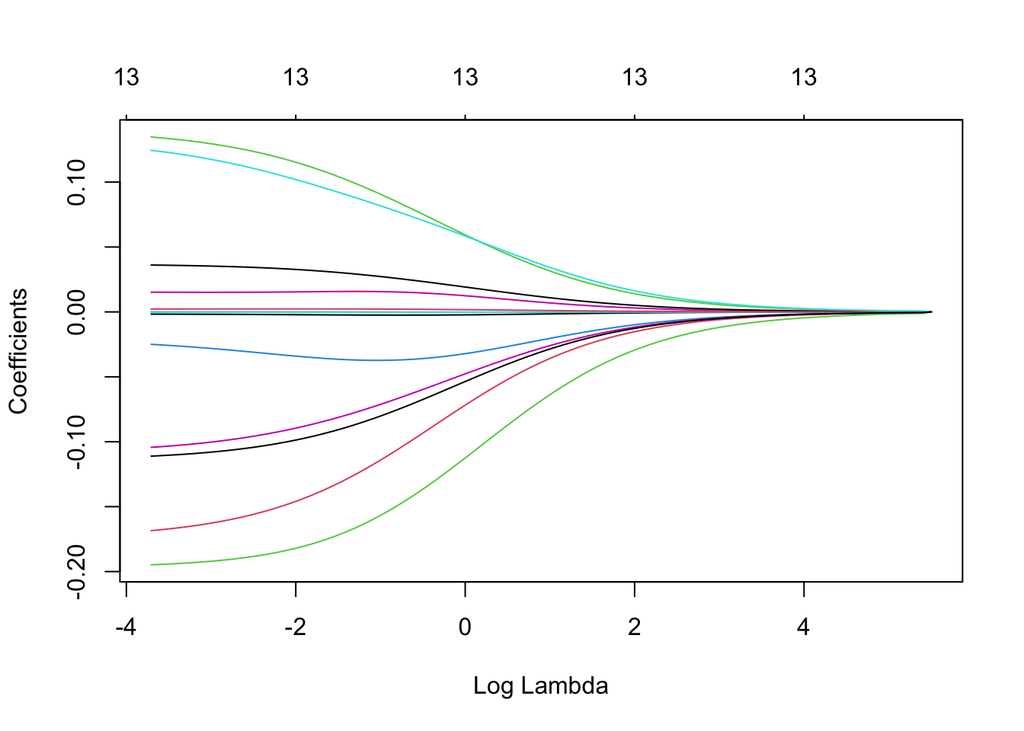

```r
covariates <- heart_train %>%
  select(
    -target
  ) %>%
  as.matrix()



dependent <- heart_train %>%
  select(
    target
  ) %>%
  as.matrix()

fit_ridge <- glmnet(
   x = covariates,
   y = dependent,
   alpha = 0
 )

 plot(fit_ridge, xvar = "lambda")
```

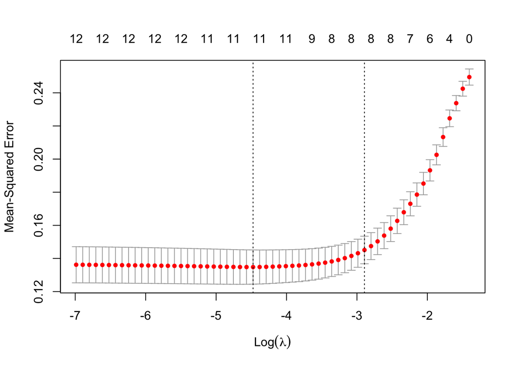

```r
cv_ridge <- cv.glmnet(x = covariates, y = dependent)

plot(cv_ridge)
```

```r
# 1 se under for simplicity:
heart_ridge_1se <- coef(cv_ridge, s = "lambda.1se")
heart_ridge_1se
```

```
## 14 x 1 sparse Matrix of class "dgCMatrix"
##                       s1
## (Intercept)  0.364343539
## age          .
## sex         -0.073692316
## cp           0.113956589
## trestbps     .
## chol         .
## fbs          .
## restecg      .
## thalach      0.001745572
## exang       -0.158700261
## oldpeak     -0.014949472
## slope        0.084888547
## ca          -0.087247488
## thal        -0.058381572
```

```r
# minimum:
heart_ridge_min <- coef(cv_ridge, s = "lambda.min")
heart_ridge_min
```

```
## 14 x 1 sparse Matrix of class "dgCMatrix"
##                        s1
## (Intercept)  0.4904141014
## age         -0.0010037555
## sex         -0.1500612528
## cp           0.1358898685
## trestbps     .
## chol        -0.0001315901
## fbs          .
## restecg      0.0214462201
## thalach      0.0021204356
## exang       -0.1895532263
## oldpeak     -0.0205305935
## slope        0.1218633051
## ca          -0.1055011956
## thal        -0.1034601287
```

- *Q10*: What can be the problem in econometrics (as opposed to statistics) when a covariate equals zero? (We will come back to this question down the course road)
- *A10*: The problem in econometrics can be that it will essentially drops variables in the regression. In an econometrics analysis we want to derive meaning to the coefficients and therefore need to extract the relevant variables to the analysis from the error terms to meet the conditions.

```r
covariates_test <- heart_test %>%
  select(
    -target
  ) %>%
  as.matrix()

# 1 sd under:
heart_ridge_pred_1se <- predict(
  object = cv_ridge,
  newx = covariates_test,
  s = c("lambda.1se")
) %>%
  bind_cols(heart_test) %>%
  select(target, lambda.1se) %>%
  rename(pred = lambda.1se)

heart_ridge_pred_1se_decision <- heart_ridge_pred_1se %>%
  mutate(
    decision = if_else(pred < rule, "0", "1"),
  )

heart_conf_mat_ridge_1se <-
  heart_ridge_pred_1se_decision %>%
  mutate(
    target = as.factor(target),
    decision = as.factor(decision)
  ) %>%
  conf_mat(target, decision)

# Minimum:
heart_ridge_pred_min <- predict(
  object = cv_ridge,
  newx = covariates_test,
  s = c("lambda.min")
) %>%
  bind_cols(heart_test) %>%
  select(target, lambda.min) %>%
  rename(pred = lambda.min)

heart_ridge_pred_min_decision <- heart_ridge_pred_min %>%
  mutate(
    decision = if_else(pred < rule, "0", "1"),
  )

heart_conf_mat_ridge_min <-
  heart_ridge_pred_min_decision %>%
  mutate(
    target = as.factor(target),
    decision = as.factor(decision)
  ) %>%
  conf_mat(target, decision)
```

```r
# Confusion martix for the 1se under delta with ridge:
heart_conf_mat_ridge_1se
```

```
##           Truth
## Prediction  0  1
##          0 43 37
##          1  1 10
```

```r
# Confusion martix for the min delta with ridge:
heart_conf_mat_ridge_min
```

```
##           Truth
## Prediction  0  1
##          0 42 30
##          1  2 17
```

```r
# Efficiency measures for the min delta with ridge:
heart_conf_mat_ridge_1se%>%
  summary() %>%
  filter(.metric %in% c("accuracy", "sens", "spec"))
```

```
## # A tibble: 3 × 3
##   .metric  .estimator .estimate
##   <chr>    <chr>          <dbl>
## 1 accuracy binary         0.582
## 2 sens     binary         0.977
## 3 spec     binary         0.213
```

```r
# Confusion martix for the 1se under with ridge:
heart_conf_mat_ridge_min%>%
  summary() %>%
  filter(.metric %in% c("accuracy", "sens", "spec"))
```

```
## # A tibble: 3 × 3
##   .metric  .estimator .estimate
##   <chr>    <chr>          <dbl>
## 1 accuracy binary         0.648
## 2 sens     binary         0.955
## 3 spec     binary         0.362
```